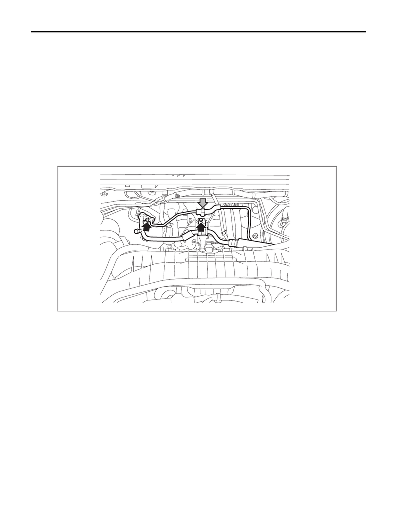

AC-61

Expansion Valve

HVAC SYSTEM (HEATER, VENTILATOR AND A/C)

18.Expansion Valve

A: REMOVAL

1) Disconnect the ground cable from battery. <Ref. to NT-5, BATTERY, NOTE, Note.>

NOTE:

For models other than STI model, disconnect the ground terminal from battery sensor.

2) Using the refrigerant recovery system, discharge refrigerant. <Ref. to AC-26, PROCEDURE, Refrigerant

Recovery Procedure.>

3) Remove the intercooler.

• Except for STI model: <Ref. to IN(w/o STI)-38, REMOVAL, Intercooler.>

• STI model: <Ref. to IN(STI)-13, REMOVAL, Intercooler.>

4) Detach the clips and bolts, and detach the hose - pressure suction and the pipe - evaporator cooling.

CAUTION:

Seal the disconnected hose, pipe and engaging part of expansion valve with a plug or vinyl tape to

prevent foreign matter from entering.

AC-03537

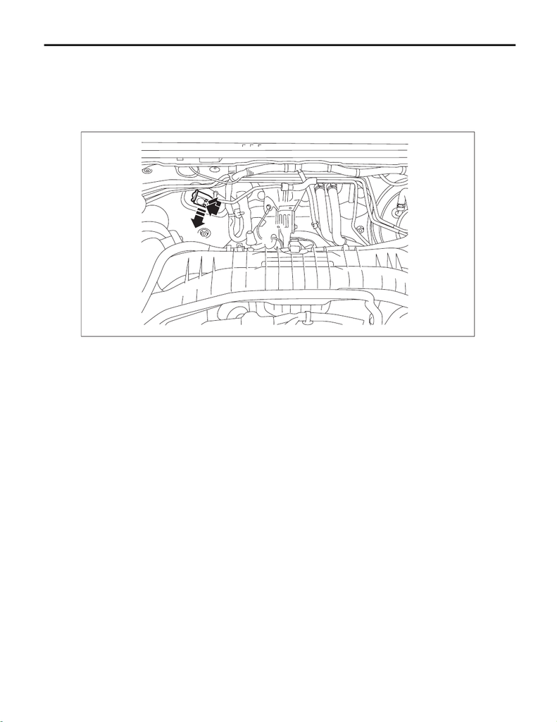

AC-62

Expansion Valve

HVAC SYSTEM (HEATER, VENTILATOR AND A/C)

5) Remove the bolt, and remove the expansion valve - cooling.

CAUTION:

Seal the pipe and engaging part of expansion valve with a plug or vinyl tape to prevent foreign matter

from entering.

Preparation tool:

Hexagon wrench: 4 mm (0.16 in)

B: INSTALLATION

CAUTION:

Replace the O-rings with new parts, and then apply compressor oil.

1) Install the expansion valve.

Tightening torque:

5 N·m (0.5 kgf-m, 3.7 ft-lb)

2) Install the hose - pressure suction and the pipe - evaporator cooling.

Tightening torque:

7.5 N·m (0.8 kgf-m, 5.5 ft-lb)

3) Install the intercooler.

• Except for STI model: <Ref. to IN(w/o STI)-41, INSTALLATION, Intercooler.>

• STI model: <Ref. to IN(STI)-14, INSTALLATION, Intercooler.>

4) Connect the battery ground terminal. <Ref. to NT-5, BATTERY, NOTE, Note.>

NOTE:

For models other than STI model, connect the ground terminal to battery sensor.

5) Charge refrigerant. <Ref. to AC-27, PROCEDURE, Refrigerant Charging Procedure.>

AC-03538